# **Tree and Tree Operations**

Tree represents the nodes connected by edges. It is a non-linear data structure. It has the following properties.

One node is marked as Root node.

Every node other than the root is associated with one parent node.

Each node can have an arbiatry number of chid node.

# **Binary Search Tree (BST)**

A Binary Search Tree (BST) is a tree in which all the nodes follow the below-mentioned properties −

The left sub-tree of a node has a key less than or equal to its parent node's key.

The right sub-tree of a node has a key greater than to its parent node's key.

[figure not shown]

A Binary Tree node contains following parts.

Data

Pointer to left child

Pointer to right child

## **Create Root**

```python
class Node:

    def __init__(self, data):

        self.left = None
        self.right = None
        self.data = data


    def PrintTree(self):
        print(self.data)

root = Node(10)

root.PrintTree()
```

```
10
```

## **Inserting into a Tree**

```python
class Node:

    def __init__(self, data):

        self.left = None
        self.right = None
        self.data = data

    def insert(self, data):
    # Compare the new value with the parent node
          if data < self.data:
              if self.left is None:
                  self.left = Node(data)
              else:
                  self.left.insert(data)
          elif data > self.data:
              if self.right is None:
                  self.right = Node(data)
              else:
                  self.right.insert(data)
# Print the tree
    def PrintTree(self):
        if self.left:
            self.left.PrintTree()
        print( self.data),
        if self.right:
            self.right.PrintTree()

# Use the insert method to add nodes
root = Node(12)
root.insert(6)
root.insert(14)
root.insert(3)

root.PrintTree()
```

```
3
6
12
14
```

# **Traversing a Tree**

Traversal is a process to visit all the nodes of a tree and may print their values too. Because, all nodes are connected via edges (links) we always start from the root (head) node. That is, we cannot randomly access a node in a tree. There are three ways which we use to traverse a tree −

In-order Traversal

Pre-order Traversal

Post-order Traversal

## **In-order Traversal**

In this traversal method, the left subtree is visited first, then the root and later the right sub-tree. We should always remember that every node may represent a subtree itself.

```python
class Node:

    def __init__(self, data):

        self.left = None
        self.right = None
        self.data = data
# Insert Node
    def insert(self, data):
    # Compare the new value with the parent node
          if data < self.data:
              if self.left is None:
                  self.left = Node(data)
              else:
                  self.left.insert(data)
          elif data > self.data:
              if self.right is None:
                  self.right = Node(data)
              else:
                  self.right.insert(data)
# Print the Tree
    def PrintTree(self):
        if self.left:
            self.left.PrintTree()
        print( self.data),
        if self.right:
            self.right.PrintTree()

# Inorder traversal
# Left -> Root -> Right
    def inorderTraversal(self, root):
        res = []
        if root:
            res = self.inorderTraversal(root.left)
            res.append(root.data)
            res = res + self.inorderTraversal(root.right)
        return res

root = Node(27)
root.insert(14)
root.insert(35)
root.insert(10)
root.insert(19)
root.insert(31)
root.insert(42)
print(root.inorderTraversal(root))
```

```
[10, 14, 19, 27, 31, 35, 42]
```

## **Pre-order Traversal**

In this traversal method, the root node is visited first, then the left subtree and finally the right subtree.

```python
class Node:

    def __init__(self, data):

        self.left = None
        self.right = None
        self.data = data
# Insert Node
    def insert(self, data):
    # Compare the new value with the parent node
          if data < self.data:
              if self.left is None:
                  self.left = Node(data)
              else:
                  self.left.insert(data)
          elif data > self.data:
              if self.right is None:
                  self.right = Node(data)
              else:
                  self.right.insert(data)

# Print the Tree
    def PrintTree(self):
        if self.left:
            self.left.PrintTree()
        print( self.data),
        if self.right:
            self.right.PrintTree()

# Preorder traversal
# Root -> Left ->Right
    def PreorderTraversal(self, root):
        res = []
        if root:
            res.append(root.data)
            res = res + self.PreorderTraversal(root.left)
            res = res + self.PreorderTraversal(root.right)
        return res

root = Node(27)
root.insert(14)
root.insert(35)
root.insert(10)
root.insert(19)
root.insert(31)
root.insert(42)
print(root.PreorderTraversal(root))
```

```
[27, 14, 10, 19, 35, 31, 42]
```

## **Post-order Traversal**

In this traversal method, the root node is visited last, hence the name. First we traverse the left subtree, then the right subtree and finally the root node.

```python
class Node:

    def __init__(self, data):

        self.left = None
        self.right = None
        self.data = data
# Insert Node
    def insert(self, data):
    # Compare the new value with the parent node
          if data < self.data:
              if self.left is None:
                  self.left = Node(data)
              else:
                  self.left.insert(data)
          elif data > self.data:
              if self.right is None:
                  self.right = Node(data)
              else:
                  self.right.insert(data)

# Print the Tree
    def PrintTree(self):
        if self.left:
            self.left.PrintTree()
        print( self.data),
        if self.right:
            self.right.PrintTree()

# Postorder traversal
# Left ->Right -> Root
    def PostorderTraversal(self, root):
        res = []
        if root:
            res = self.PostorderTraversal(root.left)
            res = res + self.PostorderTraversal(root.right)
            res.append(root.data)
        return res

root = Node(27)
root.insert(14)
root.insert(35)
root.insert(10)
root.insert(19)
root.insert(31)
root.insert(42)
print(root.PostorderTraversal(root))
root.PrintTree()
```

```
[10, 19, 14, 31, 42, 35, 27]
10
14
19
27
31
35
42
```

```python
class Node:

    def __init__(self, data):

        self.left = None
        self.right = None
        self.data = data

# Insert method to create nodes
    def insert(self, data):
    # Compare the new value with the parent node
          if data < self.data:
              if self.left is None:
                  self.left = Node(data)
              else:
                  self.left.insert(data)
          elif data > self.data:
              if self.right is None:
                  self.right = Node(data)
              else:
                  self.right.insert(data)
# findval method to compare the value with nodes
    def findval(self, lkpval):
        if lkpval < self.data:
            if self.left is None:
                return str(lkpval)+" Not Found"
            return self.left.findval(lkpval)
        elif lkpval > self.data:
            if self.right is None:
                return str(lkpval)+" Not Found"
            return self.right.findval(lkpval)
        else:
            print(str(self.data) + ' is found')
# Print the tree
    def PrintTree(self):
        if self.left:
            self.left.PrintTree()
        print( self.data),
        if self.right:
            self.right.PrintTree()


root = Node(12)
root.insert(6)
root.insert(14)
root.insert(3)
print(root.findval(7))
print(root.findval(14))
```

```
7 Not Found
14 is found
None
```

## Full Binary Tree

A Binary Tree is a full binary tree if every node has 0 or 2 children. The following are the examples of a full binary tree. We can also say a full binary tree is a binary tree in which all nodes except leaf nodes have two children.

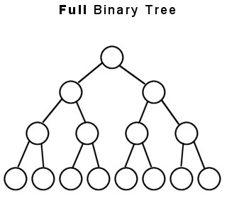

## Complete Binary Tree:

A Binary Tree is a complete Binary Tree if all the levels are completely filled except possibly the last level and the last level has all keys as left as possible

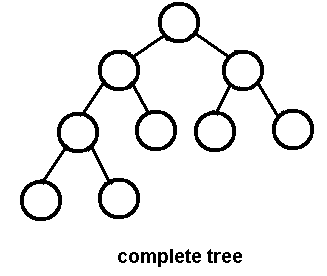

## Perfect Binary Tree

A Binary tree is a Perfect Binary Tree in which all the internal nodes have two children and all leaf nodes are at the same level.

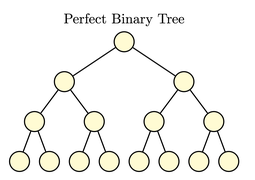

## Balanced Binary Tree

A binary tree is balanced if the height of the tree is O(Log n) where n is the number of nodes.

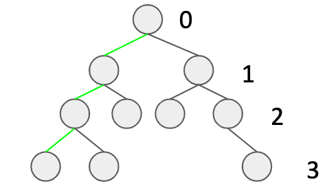

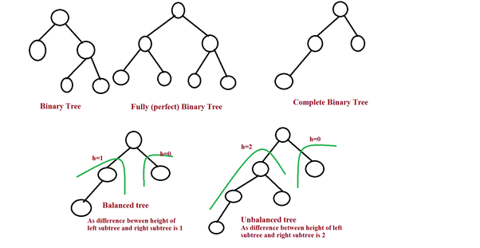

```python
class Node:

    def __init__(self, data):

        self.left = None
        self.right = None
        self.data = data

    def insert(self, data):
    # Compare the new value with the parent node
          if data < self.data:
              if self.left is None:
                  self.left = Node(data)
              else:
                  self.left.insert(data)
          elif data > self.data:
              if self.right is None:
                  self.right = Node(data)
              else:
                  self.right.insert(data)


# Print the tree
    def PrintTree(self):
        if self.left:
            self.left.PrintTree()
        print( self.data),
        if self.right:
            self.right.PrintTree()

# Use the insert method to add nodes
root = Node(12)
root.insert(15)
root.insert(14)
root.insert(3)

root.PrintTree()
```

```
3
12
14
15
```